# SML201 Chapter 2.2

# Start with a dataset

Let’s read in the dataset for the analysis.

```r
> t.ship = read.csv(file = "/Users/billhaarlow/Desktop/SML201/titanic.csv")
```

We should refresh our memory on the properties of the dataset.

```r
> class(t.ship)  # this tells me what kind of R object this dataset is
```

```
[1] "data.frame"
```

```r
> dim(t.ship)  # 891 rows by 12 columns
```

```
[1] 891  12
```

```r
> head(t.ship)  # look at the first 6 (by default) rows of an object
```

|  | PassengerId | Survived | Pclass | Name | Sex | Age | SibSp | Parch | Ticket | Fare | Cabin | Embarked |
| --- | --- | --- | --- | --- | --- | --- | --- | --- | --- | --- | --- | --- |
| 1 | 1 | 0 | 3 | Braund, Mr. Owen Harris | male | 22 | 1 | 0 | A/5 21171 | 7.2500 |  | S |
| 2 | 2 | 1 | 1 | Cumings, Mrs. John Bradley (Florence Briggs Thayer) | female | 38 | 1 | 0 | PC 17599 | 71.2833 | C85 | C |
| 3 | 3 | 1 | 3 | Heikkinen, Miss. Laina | female | 26 | 0 | 0 | STON/O2. 3101282 | 7.9250 |  | S |
| 4 | 4 | 1 | 1 | Futrelle, Mrs. Jacques Heath (Lily May Peel) | female | 35 | 1 | 0 | 113803 | 53.1000 | C123 | S |
| 5 | 5 | 0 | 3 | Allen, Mr. William Henry | male | 35 | 0 | 0 | 373450 | 8.0500 |  | S |
| 6 | 6 | 0 | 3 | Moran, Mr. James | male | NA | 0 | 0 | 330877 | 8.4583 |  | Q |

```r
> tail(t.ship, n = 3)  # look at the last 3 rows of an object
```

|  | PassengerId | Survived | Pclass | Name | Sex | Age | SibSp | Parch | Ticket | Fare | Cabin | Embarked |
| --- | --- | --- | --- | --- | --- | --- | --- | --- | --- | --- | --- | --- |
| 889 | 889 | 0 | 3 | Johnston, Miss. Catherine Helen "Carrie" | female | NA | 1 | 2 | W./C. 6607 | 23.45 |  | S |
| 890 | 890 | 1 | 1 | Behr, Mr. Karl Howell | male | 26 | 0 | 0 | 111369 | 30.00 | C148 | C |
| 891 | 891 | 0 | 3 | Dooley, Mr. Patrick | male | 32 | 0 | 0 | 370376 | 7.75 |  | Q |

```r
> # check the data type of each column in `t.ship`
> str(t.ship, strict.width = "cut")
```

```
'data.frame':   891 obs. of  12 variables:
 $ PassengerId: int  1 2 3 4 5 6 7 8 9 10 ...
 $ Survived   : int  0 1 1 1 0 0 0 0 1 1 ...
 $ Pclass     : int  3 1 3 1 3 3 1 3 3 2 ...
 $ Name       : Factor w/ 891 levels "Abbing, Mr. Anthony",..: 109 1..
 $ Sex        : Factor w/ 2 levels "female","male": 2 1 1 1 2 2 2 2 ..
 $ Age        : num  22 38 26 35 35 NA 54 2 27 14 ...
 $ SibSp      : int  1 1 0 1 0 0 0 3 0 1 ...
 $ Parch      : int  0 0 0 0 0 0 0 1 2 0 ...
 $ Ticket     : Factor w/ 681 levels "110152","110413",..: 524 597 6..
 $ Fare       : num  7.25 71.28 7.92 53.1 8.05 ...
 $ Cabin      : Factor w/ 148 levels "","A10","A14",..: 1 83 1 57 1 ..
 $ Embarked   : Factor w/ 4 levels "","C","Q","S": 4 2 4 4 4 3 4 4 4..
```

```r
> # get the 5-number summary and the mean for each column of
> # the data frame
> summary(t.ship)
```

```
  PassengerId       Survived          Pclass
 Min.   :  1.0   Min.   :0.0000   Min.   :1.000
 1st Qu.:223.5   1st Qu.:0.0000   1st Qu.:2.000
 Median :446.0   Median :0.0000   Median :3.000
 Mean   :446.0   Mean   :0.3838   Mean   :2.309
 3rd Qu.:668.5   3rd Qu.:1.0000   3rd Qu.:3.000
 Max.   :891.0   Max.   :1.0000   Max.   :3.000

                                    Name         Sex
 Abbing, Mr. Anthony                  :  1   female:314
 Abbott, Mr. Rossmore Edward          :  1   male  :577
 Abbott, Mrs. Stanton (Rosa Hunt)     :  1
 Abelson, Mr. Samuel                  :  1
 Abelson, Mrs. Samuel (Hannah Wizosky):  1
 Adahl, Mr. Mauritz Nils Martin       :  1
 (Other)                              :885
      Age            SibSp           Parch             Ticket
 Min.   : 0.42   Min.   :0.000   Min.   :0.0000   1601    :  7
 1st Qu.:20.12   1st Qu.:0.000   1st Qu.:0.0000   347082  :  7
 Median :28.00   Median :0.000   Median :0.0000   CA. 2343:  7
 Mean   :29.70   Mean   :0.523   Mean   :0.3816   3101295 :  6
 3rd Qu.:38.00   3rd Qu.:1.000   3rd Qu.:0.0000   347088  :  6
 Max.   :80.00   Max.   :8.000   Max.   :6.0000   CA 2144 :  6
 NA's   :177                                      (Other) :852
      Fare                Cabin     Embarked
 Min.   :  0.00              :687    :  2
 1st Qu.:  7.91   B96 B98    :  4   C:168
 Median : 14.45   C23 C25 C27:  4   Q: 77
 Mean   : 32.20   G6         :  4   S:644
 3rd Qu.: 31.00   C22 C26    :  3
 Max.   :512.33   D          :  3
                  (Other)    :186
```

Let’s find answers to the list of questions that we had last time with R!

# Graphical summary: Histogram

1. What is the age distribution of the passengers?

A histogram provides a graphical display of the distribution of a variable.

[figure not shown]

Histograms for Age (in Years) for Titanic Passengers

```r
> # create the histogram for the column `Age` in `t.ship`
> hist(t.ship$Age, breaks = 30, freq = F, main = "Age Distribution for Passengers on Titanic",
+     xlab = "Age (in Years)", ylab = "Proportion per Year", border = rgb(0,
+         1, 0), col = rgb(0, 0:12, 0, max = 255))
> # we will talk about how to construct histograms in more
> # details in precept
```

How about a numerical way to summarize the Age distribution?

# Numerical summaries

Three ways to summarize the central location and the spread of a dataset:

- **Mean, standard deviation/variance**
- **Five number summary: minimum, 1st quartile, median(i.e., 2nd quartile), 3rd quartile, maximum**
- **Median, interquartile range**

## Mean, standard deviation and variance

Recall that the **mean** of a set of data points is the *average* of all the data points in the set

$$mean\_of\_a\_dataset
= \frac{pt.1 + pt.2 + ... + pt.n}{n}$$

*pt.i* stands for the $i^{th}$ data point in your dataset

Variance gives a measure of the spread of the dataset by taking the average of the squared difference between each data point and the mean of the dataset:

$$\begin{align}
& variance\_of\_dataset \\
& = \frac{(pt.1-mean)^2 + (pt.2-mean)^2 + ... + (pt.n-mean)^2}{n-1}
\end{align}$$

A question for you: Why do we need to square the difference?

Note: the mean of a dataset is the quantity that minimizes the average of the squared difference between the data points and the quantity.

Taking square root of the variance gives standard deviation an unit that is consistent with the units for the original dataset.

$$SD\_of\_dataset = \sqrt{variance\_of\_dataset}$$

## Five number summary: minimum, 1st quartile, median, 3rd quartile, maximum

Recall that 1st quartile, median and 3rd quartile are just 25th , 50th and 75th percentiles, respectively.

While mean and SD give a quick summary of the central location and the spread of a dataset, they do not provide information on the shape of the distribution; e.g., we cannot tell from the values of mean and SD whether the distribution is symmetric or if there are extreme values in the dataset.

The following three datasets have their means approximately 0 and their SDs approximately 1. However, we can see that the shapes of their distributions are quite different. The first two distributions are symmetric while the last one is skewed right (i.e., with a long right tail).

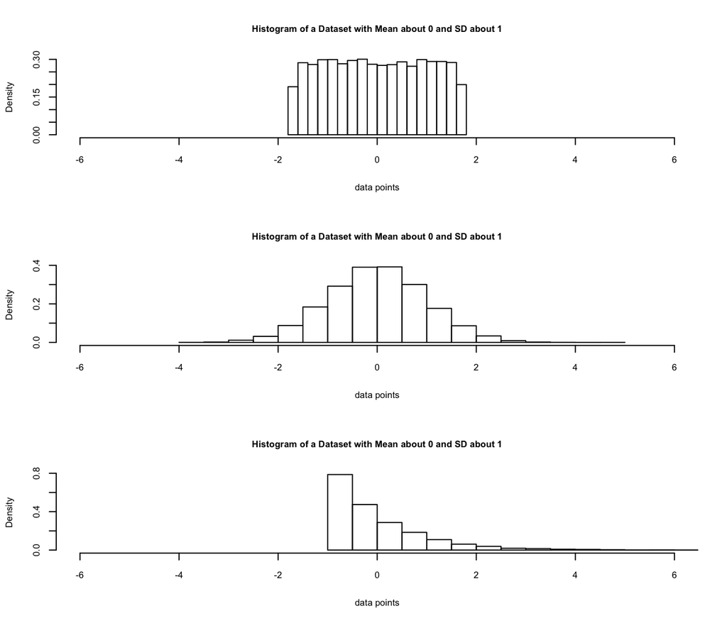

Histograms for three datasets each with mean around 0 and SD around 1

The five number summary gives a better idea of the shape of the distribution of a dataset: The median gives an idea of the central location (different definition of central location from the definition for the mean). For the three datasets above the five number summary along with the means are the following accordingly:

| Min. | 1st Qu. | Median | Mean | 3rd Qu. | Max. |
| --- | --- | --- | --- | --- | --- |
| -1.73 | -0.87 | -0.01 | 0 | 0.88 | 1.73 |
| -3.77 | -0.67 | 0.00 | 0 | 0.66 | 4.59 |
| -1.00 | -0.71 | -0.31 | 0 | 0.41 | 7.48 |

Compared to the median, the mean was affected by the extreme values in the third dataset.

## Median, interquartile range

We already know that median is just the 50th percentile.

Interquartile range (IQR) gives a measure of the spread of the “central” 50% of the data: Interquartile range = Q3-Q1

# Calculating numerical summaries

The Numerical summaries for the variable `Age` are

- **Mean, standard deviation/variance**

```r
> mean(t.ship$Age)  # you get NA because R
```

```
[1] NA
```

```r
> # does not know how you would like to handle the missing
> # values
> summary(t.ship$Age)
```

```
   Min. 1st Qu.  Median    Mean 3rd Qu.    Max.    NA's
   0.42   20.12   28.00   29.70   38.00   80.00     177
```

```r
> # the vector `Age` has 177 missing values we need to keep in
> # mind that since the number of missing values is not small
> # this might affect the accuracy of our analysis
```

```r
> mean(t.ship$Age, na.rm = T)
```

```
[1] 29.69912
```

```r
> sd(t.ship$Age, na.rm = T)
```

```
[1] 14.5265
```

```r
> var(t.ship$Age, na.rm = T)
```

```
[1] 211.0191
```

- **Five number summary: minimum, 1st quartile, median(i.e., 2nd quartile), 3rd quartile, maximum**

```r
> summary(t.ship$Age)[-4]
```

```
   Min. 1st Qu.  Median 3rd Qu.    Max.    NA's
  0.420  20.125  28.000  38.000  80.000 177.000
```

The minimum age of the passengers is .42 year, 20.12 is the 1st quartile, 28 is the median age, 38 is the 3rd quartile and the oldest passenger is 80 years old.

- **Median, interquartile range**

```r
> # calculate the median
> median(t.ship$Age, na.rm = T)
```

```
[1] 28
```

Three ways to find the interquartile range:

```r
> ## first way: calculate each quantile separately first then,
> ## take the difference
> quantile(t.ship$Age, na.rm = T, p = 0.75)  # .75 quantile
```

```
75%
 38
```

```r
> quantile(t.ship$Age, na.rm = T, p = 0.25)  # .25 quantile
```

```
   25%
20.125
```

```r
> quantile(t.ship$Age, na.rm = T, p = 0.75) - quantile(t.ship$Age,
+     na.rm = T, p = 0.25)
```

```
   75%
17.875
```

```r
> ## you can use this method to calculate the difference between
> ## any two quantiles, not just the 1st and the 3rd quartiles
```

```r
> # alternatively, we can output the values of the two
> # quantiles as elements in a vector and then take the
> # difference of the two quantiles
> diff(quantile(t.ship$Age, na.rm = T, p = c(0.25, 0.75)))
```

```
   75%
17.875
```

```r
> # lastly, we can also calculate this with the `IQR()`
> # function
> IQR(t.ship$Age, na.rm = T)
```

```
[1] 17.875
```

### Exercises

We already calculated the five-number summary of the `Age` vector.

```r
> summary(t.ship$Age)
```

```
   Min. 1st Qu.  Median    Mean 3rd Qu.    Max.    NA's
   0.42   20.12   28.00   29.70   38.00   80.00     177
```

With the outputs above answer the following questions.

Question 1. Roughly what percentage of the passengers are between age 20.12 and 38?

Answer: About 50%.

```r
> summary(t.ship$Age)
```

```
   Min. 1st Qu.  Median    Mean 3rd Qu.    Max.    NA's
   0.42   20.12   28.00   29.70   38.00   80.00     177
```

Question 2. Roughly what percentage of the passengers are older than 38?

Answer: 1 - 75% = 25%.

```r
> summary(t.ship$Age)
```

```
   Min. 1st Qu.  Median    Mean 3rd Qu.    Max.    NA's
   0.42   20.12   28.00   29.70   38.00   80.00     177
```

Question 3. Suppose that about 67.5% of the passengers have ages that are less than `x`; `x` is called the ______ quantile. Find out what age this quantile corresponds to.

Answer: The age that about 67.5% of the passengers are younger than is called the $\underline{.675}$ quantile. The age this .675 quantile corresponds to is 35.

```r
> quantile(t.ship$Age, p = 0.675, na.rm = T)
```

```
67.5%
   35
```

Question 4. Draw the histogram for the ticket prices and suggest R to use about 30 bins for the histogram.

Answer:

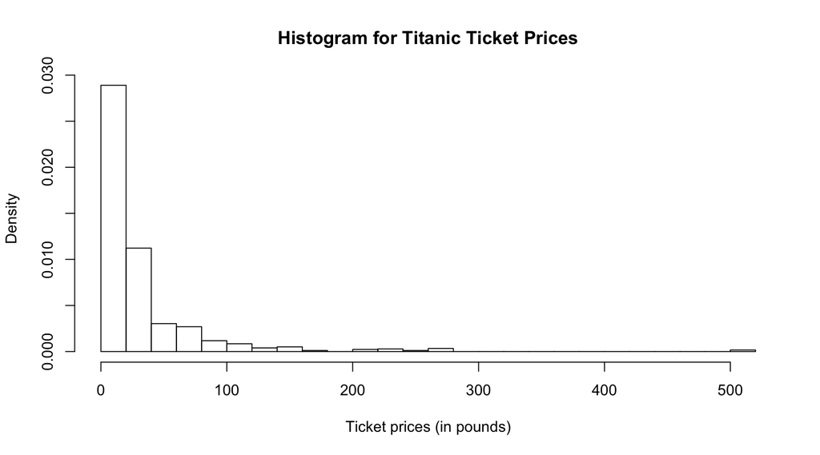

```r
> hist(t.ship$Fare, freq = F, xlab = "Ticket prices (in pounds)",
+     main = "Histogram for Titanic Ticket Prices", breaks = 30)
```

```r
> max(t.ship$Fare)  # some tickets seem to be a lot more expensive than the rest
```

```
[1] 512.3292
```

We see that some people paid a lot more than the rest of the passengers for their tickets. Who are these people? We can subset the part of the data that are about the passenger with the highest ticket price a condition:

```r
> t.ship[t.ship$Fare == max(t.ship$Fare), ]
```

|  | PassengerId | Survived | Pclass | Name | Sex | Age | SibSp | Parch | Ticket | Fare | Cabin | Embarked |
| --- | --- | --- | --- | --- | --- | --- | --- | --- | --- | --- | --- | --- |
| 259 | 259 | 1 | 1 | Ward, Miss. Anna | female | 35 | 0 | 0 | PC 17755 | 512.3292 |  | C |
| 680 | 680 | 1 | 1 | Cardeza, Mr. Thomas Drake Martinez | male | 36 | 0 | 1 | PC 17755 | 512.3292 | B51 B53 B55 | C |
| 738 | 738 | 1 | 1 | Lesurer, Mr. Gustave J | male | 35 | 0 | 0 | PC 17755 | 512.3292 | B101 | C |

```r
> # Note: t.ship$Fare == max(t.ship$Fare) is a condition and
> # will return a TRUE-FALSE vector (i.e., a logical vector)
>
> # you can extract out elements of a vector by using a logical
> # vector that has the same length; e.g.,
> c(3, 8, 1, 9)[c(T, F, F, T)]
```

```
[1] 3 9
```

You can generalize the technique of extracting elements out from a vector with logical argument to extract elements out of other R objects. Here we will demonstrate the technique with a data frame.

```r
> # create a small data frame for the demonstration
>
> toy = t.ship[1:6, 1:3]
> toy
```

|  | PassengerId | Survived | Pclass |
| --- | --- | --- | --- |
| 1 | 1 | 0 | 3 |
| 2 | 2 | 1 | 1 |
| 3 | 3 | 1 | 3 |
| 4 | 4 | 1 | 1 |
| 5 | 5 | 0 | 3 |
| 6 | 6 | 0 | 3 |

```r
> # I just want to extract out rows 1, 2, 6:
>
> toy[c(T, T, F, F, F, T), ]
```

|  | PassengerId | Survived | Pclass |
| --- | --- | --- | --- |
| 1 | 1 | 0 | 3 |
| 2 | 2 | 1 | 1 |
| 6 | 6 | 0 | 3 |

```r
> # you can also combine the conditions with & (and), | (or) or
> # ! (not); e.g.,
> c(3, 8, 1, 9)[c(T, F, F, T) & c(T, F, T, F)]
```

```
[1] 3
```

```r
> c(3, 8, 1, 9)[c(T, F, F, T) | c(T, F, T, F)]
```

```
[1] 3 1 9
```

```r
> c(3, 8, 1, 9)[!(c(T, F, F, T) & c(T, F, T, F))]
```

```
[1] 8 1 9
```

Is there anyone else paying nearly this much for their tickets? We can sort the ticket prices in a decreasing order:

```r
> sort(t.ship$Fare, decreasing = T)
```

```
  [1] 512.3292 512.3292 512.3292 263.0000 263.0000 263.0000 263.0000
  [8] 262.3750 262.3750 247.5208 247.5208 227.5250 227.5250 227.5250
 [15] 227.5250 221.7792 211.5000 211.3375 211.3375 211.3375 164.8667
 [22] 164.8667 153.4625 153.4625 153.4625 151.5500 151.5500 151.5500
 [29] 151.5500 146.5208 146.5208 135.6333 135.6333 135.6333 134.5000
 [36] 134.5000 133.6500 133.6500 120.0000 120.0000 120.0000 120.0000
 [43] 113.2750 113.2750 113.2750 110.8833 110.8833 110.8833 110.8833
 [50] 108.9000 108.9000 106.4250 106.4250  93.5000  93.5000  91.0792
 [57]  91.0792  90.0000  90.0000  90.0000  90.0000  89.1042  89.1042
 [64]  86.5000  86.5000  86.5000  83.4750  83.4750  83.1583  83.1583
 [71]  83.1583  82.1708  82.1708  81.8583  80.0000  80.0000  79.6500
 [78]  79.6500  79.6500  79.2000  79.2000  79.2000  79.2000  78.8500
 [85]  78.8500  78.2667  78.2667  77.9583  77.9583  77.9583  77.2875
 [92]  77.2875  76.7292  76.7292  76.7292  76.2917  75.2500  73.5000
 [99]  73.5000  73.5000  73.5000  73.5000  71.2833  71.0000  71.0000
```

[output cut: 113 more lines]

```r
> # by default `decreasing` is set to `FALSE` so sort() sorts
> # the elements in a vector in an increasing order; the
> # default setting in sort() also removes the missing values
> # in sort()
```

The list above is too long; in general you don’t want to print out the irrelevant figures for your analysis unless it’s necessary. let’s look at just the top 20 prices.

```r
> head(sort(t.ship$Fare, decreasing = T), n = 20)
```

```
 [1] 512.3292 512.3292 512.3292 263.0000 263.0000 263.0000 263.0000
 [8] 262.3750 262.3750 247.5208 247.5208 227.5250 227.5250 227.5250
[15] 227.5250 221.7792 211.5000 211.3375 211.3375 211.3375
```

```r
> # if we just want to sort the prices in an increasing order
> # we don't need to include the argument `decreasing`
> head(sort(t.ship$Fare), n = 20)
```

```
 [1] 0.0000 0.0000 0.0000 0.0000 0.0000 0.0000 0.0000 0.0000 0.0000
[10] 0.0000 0.0000 0.0000 0.0000 0.0000 0.0000 4.0125 5.0000 6.2375
[19] 6.4375 6.4500
```

Note that the most expensive price is almost twice as much as the second highest one! A price that falls well outside the main price range is called an outlier; we are almost certain that the top price is an outlier by just looking at the histogram but what about other prices that are to the far right of the histogram?

# Additional numerical summary statistics

## Outliers

An **Outlier** is an observation that falls well outside the main range of the data. We should treat outliers with cautions; sometimes outliers occur due to recording errors and other times outliers actually provide us insightful information about the data.

There are different rules to identify outliers. One set of rules that is commonly used defines an outlier to be a data point that falls more than 1.5 times of the IQR below Q1 or above the Q3 (see sketch on the board in lecture).

In addition, a boxplot provides a graphical way to identify outliers.

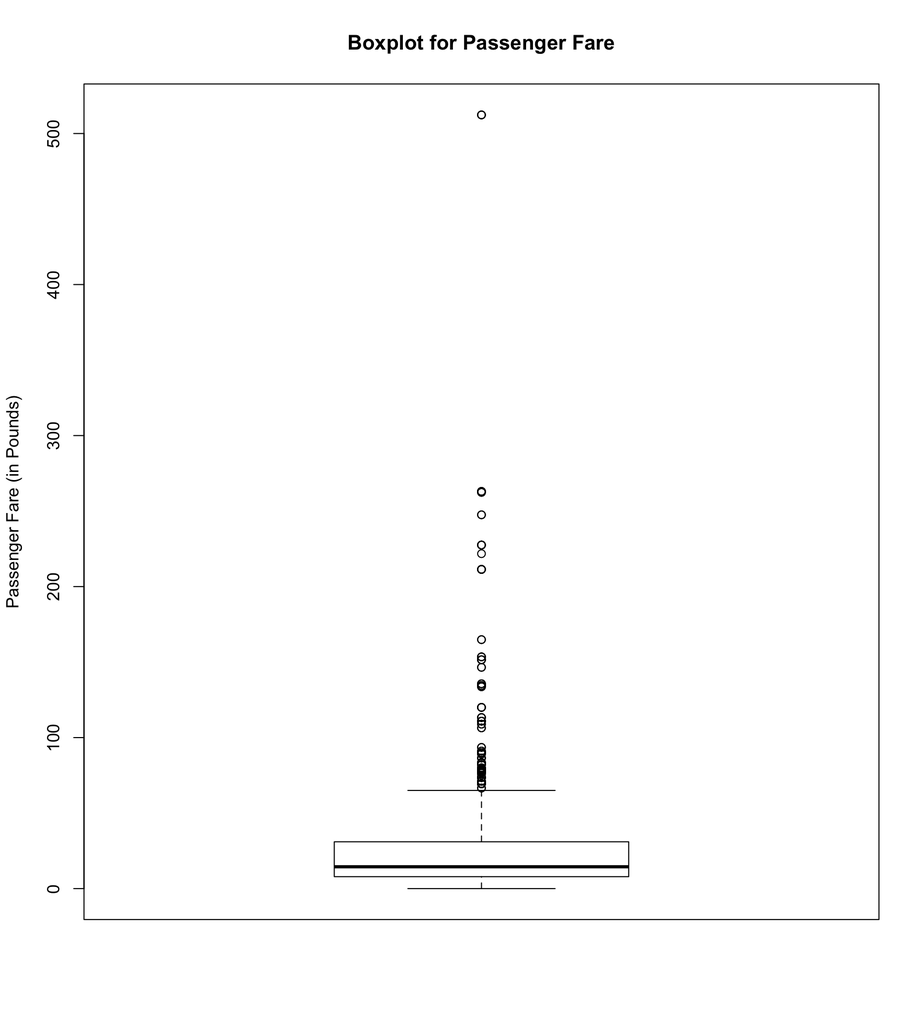

```r
> boxplot(t.ship$Fare, main = "Boxplot for Passenger Fare", ylab = "Passenger Fare (in Pounds)")
```

Please see details about boxplots in lecture.

## Mode

The **modes** of a dataset are the peaks on the histogram for the dataset. E.g., on the histograms for three datasets each with mean around 0 and SD around 1 we see that the first dataset has no mode, the second and the third dataset each has one mode. The location of the mode tells us on which part of the x-interval the data has high frequency. The most prominent mode is called the **major mode**–there could be more than one major mode depending on the distribution. The less prominent ones are called the minor modes.

Let’s find out the answers to a few more questions that we had last time!

### Exercises

Question 5. Observe the histogram for `Age`; are there any modes?

There is one major mode around age 21 and there is a minor mode around age 1.

Question 6. *Exactly* how many passengers are between age 20 and 22, inclusively? (Hint: When you apply mathematical operations on a vector with logical arguments `R` treats logical arguments as numbers; `TRUE` is treated as 1 and `FALSE` is treated as 0.)

```r
> sum(t.ship$Age >= 20 & t.ship$Age <= 22, na.rm = T)
```

```
[1] 67
```

- How much is the most expensive ticket?
- How much is the cheapest ticket?

```r
> range(t.ship$Fare)
```

```
[1]   0.0000 512.3292
```

Question 7. What are the ages of the four youngest passengers on the ship?

```r
> sort(t.ship$Age)[1:20]
```

```
 [1] 0.42 0.67 0.75 0.75 0.83 0.83 0.92 1.00 1.00 1.00 1.00 1.00 1.00
[14] 1.00 2.00 2.00 2.00 2.00 2.00 2.00
```

```r
> # sort() sorts the elements in a vector in increasing order
> # (by default); the default setting in sort() also removes
> # the missing values in sort()
```

The four youngest passengers on the ship are of ages:

```r
> sort(t.ship$Age)[1:4]
```

```
[1] 0.42 0.67 0.75 0.75
```

Question 8. Consider the non-missing Age values. Are there anyone that seems to be younger or older than the majority of the passengers? Use the outlier rule we discussed in class to identify these passengers.

We leave this as an exercises for you.

> 66.0 65.0 71.0 70.5 65.0 65.0 71.0 80.0 70.0 70.0 74.0

or with no repeats:

> 65.0 66.0 70.0 70.5 71.0 74.0 80.0

Question 9. Are there people paying much more/less than the majority of the passengers?

Note that you can use the function `unique()` to extract out the unique elements in a vector; see an example of how to use `unique()` near the end of this chapter.

# Technical details related to concepts and functions covered in this chapter

## Vector

- A vector is a (1-dimensional) collection of ordered **homogeneous** elements (i.e., all elements are of the same data type) ; the common data types in R are integer, numeric, logical, character/string, factor and complex (we will not use data with complex data type in this course). Below are some example of vectors with elements of different data types:

**Integer**

```r
> 7:11  # integer
```

```
[1]  7  8  9 10 11
```

```r
> class(7:11)
```

```
[1] "integer"
```

```r
> # class() tells you the object type of the input argument
> # However, when the input argument is a vector class() will
> # tell you a bit more: it will tell you the data type of the
> # elements in the vector--note that all the elements in a
> # vector always have the same data type.
```

**numeric**

```r
> c(3.4, 9.7, 14.2, 1.5)
```

```
[1]  3.4  9.7 14.2  1.5
```

```r
> class(c(3.4, 9.7, 14.2, 1.5))
```

```
[1] "numeric"
```

**Logical–binary. TRUE or FALSE**

```r
> c(T, T, F)  # create a logical vector
```

```
[1]  TRUE  TRUE FALSE
```

```r
> # You can also use TRUE/FALSE instead of T/F
>
> class(c(T, T, F))
```

```
[1] "logical"
```

```r
> (3:7) > 4  # returns a vector of logical elements
```

```
[1] FALSE FALSE  TRUE  TRUE  TRUE
```

```r
> class((3:7) > 4)
```

```
[1] "logical"
```

```r
> !((3:7) > 4)  # negation operator; i.e., 'not'
```

```
[1]  TRUE  TRUE FALSE FALSE FALSE
```

**Character/string–each element in vector is one or more characters**

```r
> y = c("a", "bc", "def")
> length(y)  # length of vector
```

```
[1] 3
```

```r
> nchar(y)  # number of characters of each element
```

```
[1] 1 2 3
```

**Factors–each element is a category**

```r
> `?`(factor)
> factor(c("yes", "yes", "no", "yes", "no"))
```

```
[1] yes yes no  yes no
Levels: no yes
```

```r
> factor(c("yes", "yes", "no", "yes", "no"), levels = c("yes",
+     "no"))
```

```
[1] yes yes no  yes no
Levels: yes no
```

We will talk about factors in more details later in the course.

### Construction and Extraction

```r
> ##### For vectors
>
> how.happy = c(miserable = -2, low = -1, all.right = 0, cheerful = 1,
+     ecstatic = 2)
> names(how.happy)
```

```
[1] "miserable" "low"       "all.right" "cheerful"  "ecstatic"
```

```r
> # another way to construct this vector
> how.happy = (-2):2
> names(how.happy) = c("miserable", "low", "all.right", "cheerful",
+     "ecstatic")
> # need to have quotation marks because the entries are
> # characters
>
> # R starts indexing with 1 and use '[]' for indices
>
> ## Five ways to extract elements of a vector
>
> # Way 1
> how.happy[c(2, 4, 5)]  # Inclusion by position
```

```
     low cheerful ecstatic
      -1        1        2
```

```r
> # Way 2
> how.happy[-c(1, 3)]  # Exclusion by position
```

```
     low cheerful ecstatic
      -1        1        2
```

```r
> # Way 3
> how.happy[c("low", "cheerful", "ecstatic")]  # By name
```

```
     low cheerful ecstatic
      -1        1        2
```

```r
> # Way 4
> how.happy[how.happy >= 1]  # By logical index
```

```
cheerful ecstatic
       1        2
```

```r
> how.happy[c(F, F, F, T, T)]  # same as above
```

```
cheerful ecstatic
       1        2
```

```r
> # note that the logical vector in '[]' needs to have the same
> # length as how.happy
>
> # Way 5
> how.happy[]  # No index (include everything)
```

```
miserable       low all.right  cheerful  ecstatic
       -2        -1         0         1         2
```

```r
> # This is useful when I want to reassign values to x--see
> # below
```

### Assignment

```r
> ## The same indexing method can be used to assign values to
> ## elements of a vector.
>
> # Way 1
> how.happy[c(2, 4, 5)] = c(-10, 10, 20)  # Inclusion by position
>
>
> # Way 2
> how.happy[-c(2, 4, 5)] = c(-20, 0)  # Exclusion by position
> how.happy
```

```
miserable       low all.right  cheerful  ecstatic
      -20       -10         0        10        20
```

```r
> # Way 3
> how.happy[c("low", "all.right", "cheerful")] = c(-200, 0, 200)  # By name
> how.happy
```

```
miserable       low all.right  cheerful  ecstatic
      -20      -200         0       200        20
```

```r
> # Way 4
> how.happy[how.happy > 10] = c(2000, 4000)  # By logical index
> how.happy
```

```
miserable       low all.right  cheerful  ecstatic
      -20      -200         0      2000      4000
```

```r
> how.happy[c(F, F, F, T, T)] = c(2000, 4000)  # same as above
> # note that the logical vector in '[]' needs to have the same
> # length as how.happy
>
> # Way 5
> how.happy[] = 5  # No index (include everything)
> # This is useful when I want to reassign values to x Note:
> # this is different from
> how.happy = 5
```

### Concatenation–combining multiple vectors into one

```r
> x = 60:67
> y = 100:105
> x
```

```
[1] 60 61 62 63 64 65 66 67
```

```r
> y
```

```
[1] 100 101 102 103 104 105
```

```r
> c(x, y)
```

```
 [1]  60  61  62  63  64  65  66  67 100 101 102 103 104 105
```

### Coercion–converting the data types of the elements in a vector into one data type

```r
> class(c("a", "q"))
```

```
[1] "character"
```

```r
> class(c(F))
```

```
[1] "logical"
```

```r
> c("a", "q", F)
```

```
[1] "a"     "q"     "FALSE"
```

```r
> class(c("a", "q", F))
```

```
[1] "character"
```

```r
> # R does implicit coercion to change the data type for the
> # vector to whatever that makes sense
>
> c(T, 4.5, F)
```

```
[1] 1.0 4.5 0.0
```

```r
> class(c(T, 4.5, F))  # R codes 'T=1' and 'F=0'
```

```
[1] "numeric"
```

## Data frame

A data frame could have heterogeneous elements; i.e., its columns can have different data types.

Since the columns of a data frame need to have the same length, a data frame has a similar appearance of a matrix, except that the data types of the entries in a data frame can change from column to column while all the elements of a matrix need to have the same data type.

### Exercise

Question 10. The following R object has to be a data frame, not a matrix. Why?

```r
> head(iris)
```

|  | Sepal.Length | Sepal.Width | Petal.Length | Petal.Width | Species |
| --- | --- | --- | --- | --- | --- |
| 1 | 5.1 | 3.5 | 1.4 | 0.2 | setosa |
| 2 | 4.9 | 3.0 | 1.4 | 0.2 | setosa |
| 3 | 4.7 | 3.2 | 1.3 | 0.2 | setosa |
| 4 | 4.6 | 3.1 | 1.5 | 0.2 | setosa |
| 5 | 5.0 | 3.6 | 1.4 | 0.2 | setosa |
| 6 | 5.4 | 3.9 | 1.7 | 0.4 | setosa |

To see the column names of a data frame we can use the function `names()` or `colnames()`.

```r
> d = data.frame(let = c("a", "p"), val = 1:2, t = c(7.6, 5.1))
>
> d
```

| let | val | t |
| --- | --- | --- |
| a | 1 | 7.6 |
| p | 2 | 5.1 |

```r
> names(d)  # names of the elements of a data frame
```

```
[1] "let" "val" "t"
```

```r
> colnames(d)  # Remember that this also works for a matrix
```

```
[1] "let" "val" "t"
```

### Indexing, extraction and concatenation

Because a data frame has a similar appearance of a matrix we can index a data frame with the conventional matrix index notation used in mathematics: `[row index, column index]`.

```r
> class(d[, 2])  # a vector
```

```
[1] "integer"
```

In addition, we can extract a column by name using the $ symbol or by using its column index with `[[]]`:

```r
> class(d$val)  # a vector
```

```
[1] "integer"
```

```r
> class(d[[2]])  # a vector
```

```
[1] "integer"
```

Last, we need to be careful about using `[]`. The output will actually stay in the data frame object type:

```r
> class(d[2])  # still a data frame, not a column
```

```
[1] "data.frame"
```

```r
> # Note that it makes sense to do this
> class(d[2:3])  # this means to extract out the 2nd and 3rd columns
```

```
[1] "data.frame"
```

```r
> # but not this class(d[[2:3]]) see details here
> # (https://cran.r-project.org/doc/manuals/R-lang.html#Indexing)
```

To combine multiple data frames we use the `data.frame()` function

```r
> # create another data frame to combine with d
> d2 = data.frame(let2 = c("k", "j"), val2 = 8:7)
> d2
```

| let2 | val2 |
| --- | --- |
| k | 8 |
| j | 7 |

```r
> # combine two data frames
>
> data.frame(d, d2)
```

| let | val | t | let2 | val2 |
| --- | --- | --- | --- | --- |
| a | 1 | 7.6 | k | 8 |
| p | 2 | 5.1 | j | 7 |

```r
> class(data.frame(d, d2))  # result is another data frame
```

```
[1] "data.frame"
```

## Some R programming techniques

### Vectorized calculations

An important feature of R is that it carries out **vectorized computations**. This means that R would apply basic arithmetic, as well as many built-in R functions, to *each element* of a vector. This avoids much of the looping that is used in lower-level languages. Therefore, making use of vectorized calculations often makes computations more efficient than using loops in R.

```r
> x = 1:4
> x * 5
```

```
[1]  5 10 15 20
```

```r
> x^2
```

```
[1]  1  4  9 16
```

```r
> y = 0:3
> x + y
```

```
[1] 1 3 5 7
```

```r
> sum(x, y)  # different from x + y
```

```
[1] 16
```

```r
> sum(x) + sum(y)  # same as sum(x, y)
```

```
[1] 16
```

```r
> prod(x)  # Returns the product of all the values present in its argument
```

```
[1] 24
```

```r
> diff(x)
```

```
[1] 1 1 1
```

```r
> diff(c(8, 2))
```

```
[1] -6
```

### Recycling rule

When the vectors in a calculation are of different lengths, R follows the **recycling rule**. That is, it repeats and cycles elements from the shorter one.

```r
> x = 1:5
> y = 0:2
> x + y
```

```
[1] 1 3 5 4 6
```

## Functions that help you understand an R object better

```r
> # To find out the object type for any R objects
> class(iris)  # iris is a built-in dataset in R
```

```
[1] "data.frame"
```

```r
> # For a matrix, an array or a data frame
> dim(iris)
```

```
[1] 150   5
```

```r
> # See the top or bottom part of an object
> head(iris, n = 3)
```

|  | Sepal.Length | Sepal.Width | Petal.Length | Petal.Width | Species |
| --- | --- | --- | --- | --- | --- |
| 1 | 5.1 | 3.5 | 1.4 | 0.2 | setosa |
| 2 | 4.9 | 3.0 | 1.4 | 0.2 | setosa |
| 3 | 4.7 | 3.2 | 1.3 | 0.2 | setosa |

```r
> tail(iris, n = 2)
```

|  | Sepal.Length | Sepal.Width | Petal.Length | Petal.Width | Species |
| --- | --- | --- | --- | --- | --- |
| 149 | 6.2 | 3.4 | 5.4 | 2.3 | virginica |
| 150 | 5.9 | 3.0 | 5.1 | 1.8 | virginica |

```r
> # For a vector or a list
> length(iris$Sepal.Length)
```

```
[1] 150
```

```r
> length(iris)  # Recall that a data.frame is just a special type of list
```

```
[1] 5
```

```r
> # For a matrix or a data frame
> ncol(iris)  # same as dim(iris)[2]
```

```
[1] 5
```

```r
> nrow(iris)  # same as dim(iris)[1]
```

```
[1] 150
```

```r
> # To find out the data type for each element in any R object
> str(iris)
```

```
'data.frame':   150 obs. of  5 variables:
 $ Sepal.Length: num  5.1 4.9 4.7 4.6 5 5.4 4.6 5 4.4 4.9 ...
 $ Sepal.Width : num  3.5 3 3.2 3.1 3.6 3.9 3.4 3.4 2.9 3.1 ...
 $ Petal.Length: num  1.4 1.4 1.3 1.5 1.4 1.7 1.4 1.5 1.4 1.5 ...
 $ Petal.Width : num  0.2 0.2 0.2 0.2 0.2 0.4 0.3 0.2 0.2 0.1 ...
 $ Species     : Factor w/ 3 levels "setosa","versicolor",..: 1 1 1 1 1 1 1 1 1 1 ...
```

### Other built-in functions in R

**`min()`, `max()`, `which()`**

```r
> x = c(3, 9, 1, -1, 12, -1, 5, -1)
> sum(x)/length(x)
```

```
[1] 3.375
```

```r
> mean(x)  # this takes average of the elements in x
```

```
[1] 3.375
```

```r
> min(x)  # the minimum of the elements in x
```

```
[1] -1
```

```r
> max(x)  # the maximum of the elements in x
```

```
[1] 12
```

```r
> range(x)  # range returns the minimum and the maximum of x
```

```
[1] -1 12
```

```r
> c(min(x), max(x))  # same result as range(x)
```

```
[1] -1 12
```

```r
> # To index by value
> which.max(x)  # the index of the element that equals the max of x
```

```
[1] 5
```

```r
> which.min(x)
```

```
[1] 4
```

```r
> # note that this gives you only the index of the first
> # element that equals the min of x
>
> which(x == min(x))
```

```
[1] 4 6 8
```

```r
> # this will return all indices of the elements that equals
> # the min of x
```

## Manipulating or rearranging elements in a vector: sort(), rank(), unique(), order(), %in%

**sort()**

The function sort() sorts a vector into ascending or descending order.

```r
> x = c(3, 9, 1, -1, 12, -1, 5, -1)
>
> x
```

```
[1]  3  9  1 -1 12 -1  5 -1
```

```r
> sort(x)
```

```
[1] -1 -1 -1  1  3  5  9 12
```

```r
> x  # Note that sort() does not change x
```

```
[1]  3  9  1 -1 12 -1  5 -1
```

```r
> sort(x, decreasing = T)
```

```
[1] 12  9  5  3  1 -1 -1 -1
```

```r
> # To see why sort() is useful
>
> pop.in.mi = c(19.75, 9, 12.78)
> # population size in millions
> names(pop.in.mi) = c("NY", "NJ", "PA")
>
> pop.in.mi
```

```
   NY    NJ    PA
19.75  9.00 12.78
```

```r
> sort(pop.in.mi)
```

```
   NJ    PA    NY
 9.00 12.78 19.75
```

```r
> # see the smallest and biggest states among the three
```

**rank()**

The function rank() returns the sample ranks of the values in a vector. Ties (i.e., equal values) and missing values can be handled in several ways.

```r
> pop.in.mi
```

```
   NY    NJ    PA
19.75  9.00 12.78
```

```r
> rank(pop.in.mi)
```

```
NY NJ PA
 3  1  2
```

```r
> rank(-pop.in.mi)  # rank in decreasing order
```

```
NY NJ PA
 1  3  2
```

**unique()**

The `unique()` function returns a vector, matrix, data frame or array just the same as the input but with duplicate elements/rows removed.

Here is an example for `unique()` on a vector.

```r
> x
```

```
[1]  3  9  1 -1 12 -1  5 -1
```

```r
> unique(x)
```

```
[1]  3  9  1 -1 12  5
```

```r
> sort(unique(x))
```

```
[1] -1  1  3  5  9 12
```

```r
> # unique also works on objects of character type
```

Here is another example for `unique()` on a matrix.

```r
> # create a matrix for the example
> m.with.duplicate.rows = matrix(c(rep(1:3, 3), 4:6), ncol = 3,
+     byrow = T)
> m.with.duplicate.rows
```

```
     [,1] [,2] [,3]
[1,]    1    2    3
[2,]    1    2    3
[3,]    1    2    3
[4,]    4    5    6
```

```r
> # `unique()` removes duplicate rows.
> unique(m.with.duplicate.rows)
```

```
     [,1] [,2] [,3]
[1,]    1    2    3
[2,]    4    5    6
```

**order()**

`order()` is often used to re-order the elements in an object according to the order in *another* object.

```r
> # order() returns a list of indices that you can use to sort
> # the input vector in a decreasing or increasing order
>
> # create vectors for this example
> v = c(8, 9, 2, 1, -1)
> v2 = 1:5
> # create a matrix for this example
> tmp.m = cbind(v, v2)
> tmp.m
```

```
      v v2
[1,]  8  1
[2,]  9  2
[3,]  2  3
[4,]  1  4
[5,] -1  5
```

```r
> # I now want to rearrange the rows according to the values in
> # v
>
> sort(v)  # the sorted v (in an increasing order) looks like this
```

```
[1] -1  1  2  8  9
```

```r
> # order(v) will give me the indices that I need to rearrange
> # the elements in v in an increasing order
> v[order(v)]  # same result as sort(v)
```

```
[1] -1  1  2  8  9
```

```r
> # I can use such indices to rearrange the rows of tmp.m so
> # that the rows are arranged according to the values in the
> # first column of the matrix
> tmp.m[order(v), ]
```

```
      v v2
[1,] -1  5
[2,]  1  4
[3,]  2  3
[4,]  8  1
[5,]  9  2
```

```r
> # Similarly, if we want to do this in a decreasing order:
> tmp.m[order(-v), ]
```

```
      v v2
[1,]  9  2
[2,]  8  1
[3,]  2  3
[4,]  1  4
[5,] -1  5
```

**%in%**

%in% is helpful for finding out if the elements of the left-object (i.e., the object on the left of `%in%`) are in the right-object

```r
> x
```

```
[1]  3  9  1 -1 12 -1  5 -1
```

```r
> c(3, 4, 5) %in% x
```

```
[1]  TRUE FALSE  TRUE
```

```r
> # This returns a vector of the same length as c(3, 4, 5) each
> # element in the resulting vector is T if that element is in
> # x, F otherwise
>
> x %in% c(3, 4, 5)
```

```
[1]  TRUE FALSE FALSE FALSE FALSE FALSE  TRUE FALSE
```

```r
> # different from the result for `c(3, 4, 5) %in% x`
```

In Summary,

- sort(): rearrange the elements of a vector;
- rank(): get the ranks of the elements of a vector;
- order(): get the indices to re-arrange the elements/rows of a vector/matrix/data frame; order() is usually used if you would like to arrange the elements in one object according to that in another object.
- unique(): get the unique elements/rows of a vector/matrix/data frame;
- %in%: check if the elements in a vector are in another vector;